# Statistical Analysis and Data Display by ggplot2

Qingyang(Kevin) Liu

May 3, 2018

### Chapter2

There is only one figure within Chapter2. All data comes from `HH` package.

#### Fig2.1

Back to Chapter2

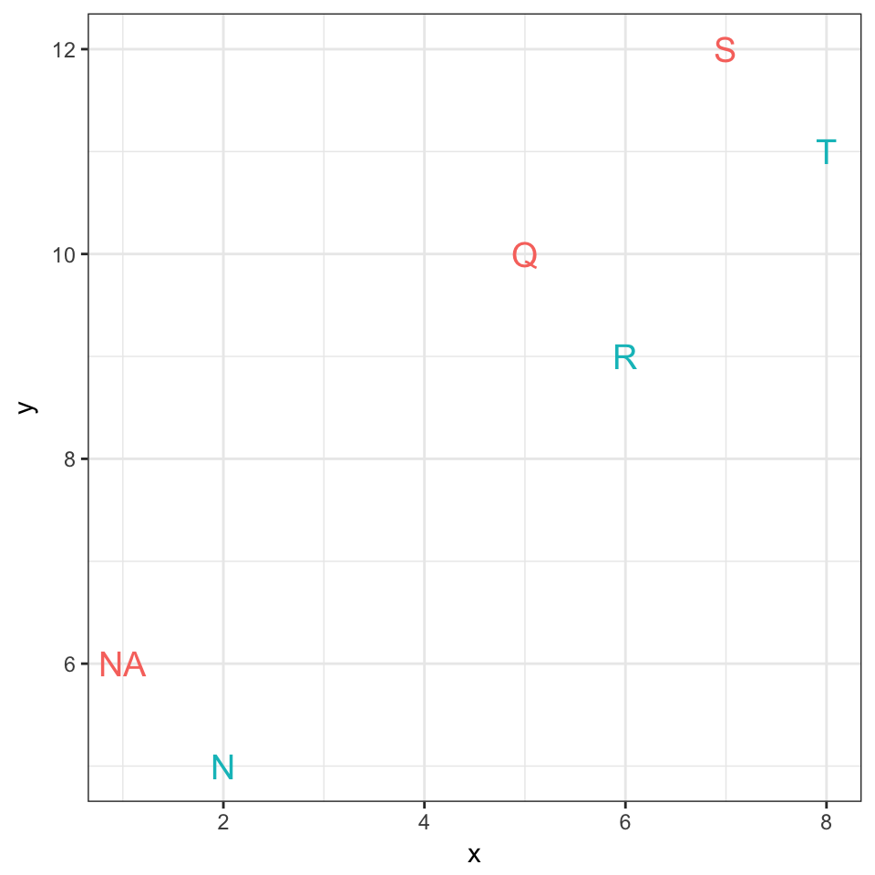

```r
library(ggplot2)

abcd <- data.frame(x=c(1, 2, NA, 4, 5, 6, 7, 8),
                   y=c(6, 5, 8, NA, 10, 9, 12, 11),
                   ch=c("NA", "N", "O", "P", "Q", "R", "S", "T"),
                   colour = rep(c("red","blue"),4),
                   stringsAsFactors=FALSE)
abcd$colour <- factor(abcd$colour,levels = c("red","blue"))

fig2.1 <- ggplot(abcd, aes(x = x, y = y, colour = colour)) +
          geom_text(aes(label = ch), size = 5) +
          theme_bw() +
          theme(legend.position = "none")

fig2.1
```

### Chapter3

There are total 24 figures within chapter 3.

#### Tab3.2

In book, table 3.2 is combined by LaTeX. Here is just a example that using `tableGrob` function can generate simple Table.

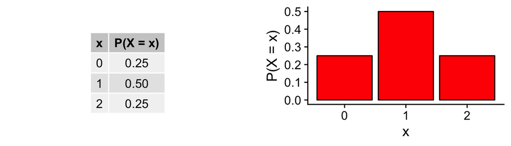

```r
library(ggplot2)
library(gridExtra)
library(grid)
library(cowplot)

df3.2 <- data.frame(x=factor(0:2), y=c(.25, .50, .25))

fig3.2 <- ggplot(df3.2, aes( x = x, y = y)) +
          geom_col(colour = "black", fill = "red") +
          ylab ("P(X = x)")

tab3.2 <- tableGrob(df3.2, row = NULL, cols = c("x","P(X = x)"))
plot_grid(tab3.2, fig3.2, nrow = 1, axis = "t")
```

#### Tab3.3

Same as table 3.2, table 3.3 is combined by LaTeX. I like the ideas using mosaic plots to showing probability mass function.

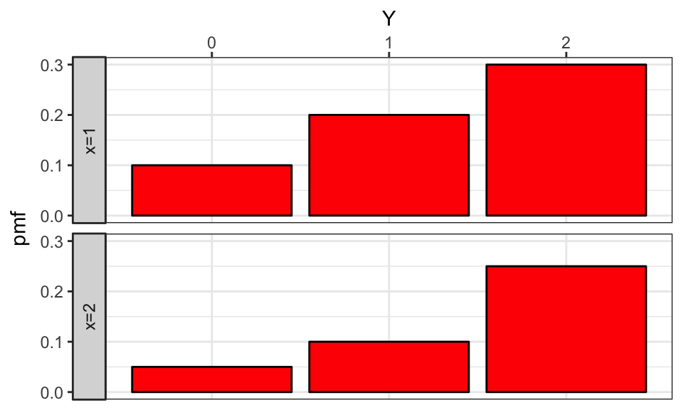

```r
pmf <- matrix(c(0.10,0.2,0.30,0.05,0.1,0.25), nrow = 6)
pmf <- data.frame(pmf)
pmf$X <- rep(c("x=1","x=2"),each = 3)
pmf$Y <- as.character(rep(0:2,2))

fig3.3.1 <- ggplot(pmf,aes(x = Y, y = pmf)) +
            geom_col(colour = "black", fill = "red") +
            facet_grid(X~., switch = "y") +
            scale_x_discrete(position = "top") +
            theme_bw()
fig3.3.1
```

Orignal figure in second row of table 3.3 has no white space between each row. I have not found function to make such change in `ggmosaic`. Same thing for figure in third row. I think the minor difference is acceptable.

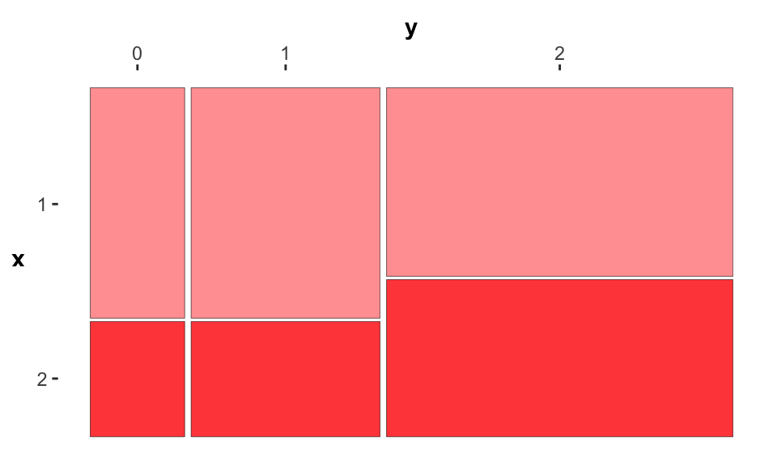

```r
library(ggmosaic)
pmf <- matrix(c(0.10,0.2,0.30,0.05,0.1,0.25), nrow = 6)
pmf <- data.frame(pmf)
pmf$X <- rep(c("x=1","x=2"),each = 3)
pmf$X <- factor(pmf$X, levels = c("x=2","x=1"))
pmf$Y <- as.character(rep(0:2,2))
pmf$Y <- factor(pmf$Y, levels = c("0","1","2"))

fig3.3.2  <- ggplot(pmf) +
             geom_mosaic(aes(weight = pmf, x = product(X,Y), fill = factor(X)), colour = "black") +
             scale_x_productlist(name = "y", position = "top") +
             scale_y_continuous(name = "x",
                                breaks = c(1/6,2/3),
                                minor_breaks = NULL,
                                labels = c("2","1")) +
             scale_fill_manual(values = c("red","#ff8888")) +
             theme_classic() +
             theme(legend.position = "none",
                   axis.title.y = element_text(angle = 180, vjust = 0.5, face = "bold"),
                   axis.title.x = element_text(face = "bold"),
                   axis.line = element_blank())

fig3.3.2
```

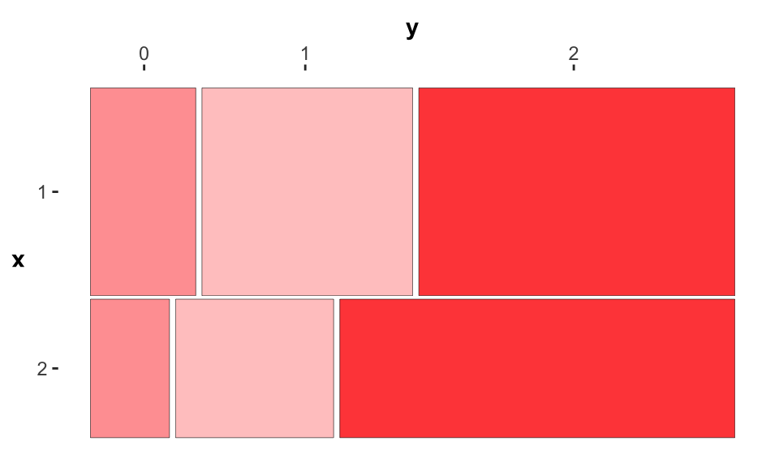

```r
fig3.3.3  <- ggplot(pmf) +
             geom_mosaic(aes(weight = pmf, x = product(Y,X), fill = factor(Y)), colour = "black") +
             coord_flip() +
             scale_fill_manual(values = c("#ff8888","#ffBBBB","red")) +
             scale_x_productlist(name = "x", labels = c("2","1")) +
             scale_y_continuous(name = "y",
                                position = "right",
                                breaks = c(1/12,1/6+1/6,1/2+1/4),
                                minor_breaks = NULL,
                                labels = c("0","1","2")) +
             theme_classic() +
             theme(legend.position = "none",
                   axis.title.y = element_text(angle = 180, vjust = 0.5, face = "bold"),
                   axis.title.x = element_text(face = "bold"),
                   axis.line = element_blank())

fig3.3.3
```

#### Fig3.2

Probability density function.

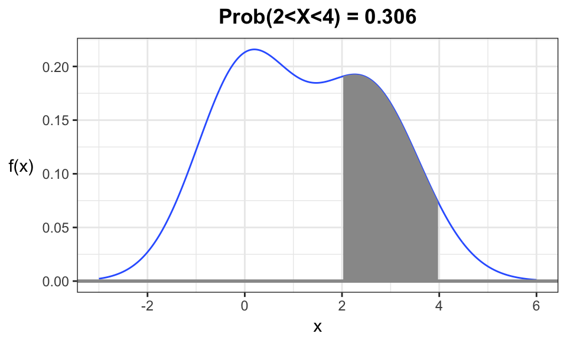

```r
xx <- seq(-3, 6, .025)
dd <- (dnorm(xx, mean=0, sd=1) + dnorm(xx, mean=2.5, sd=1.1))/2
pr <- (pnorm(c(2,4), mean=0, sd=1) + pnorm(c(2,4), mean=2.5, sd=1.1))/2
df3.2 <- data.frame(x = xx,y = dd)
df3.2b <- subset(df3.2, x > 2 & x <4)
fig3.2 <- ggplot(df3.2, aes(x = x ,y = y)) + geom_line(colour = "#3366FF") +
          geom_area(data = df3.2b, aes(x = x ,y = y), fill = "grey60") +
          geom_hline(yintercept = 0, colour = "grey60", size = 1) +
          theme_bw()+
          labs(y = "f(x)", title = "Prob(2<X<4) = 0.306") +
          theme(axis.title.y = element_text(angle = 0, vjust = 0.5),
                plot.title = element_text(hjust = 0.5, face = "bold"))

fig3.2
```

#### Fig3.3

Skewed and Symmetric Distribution

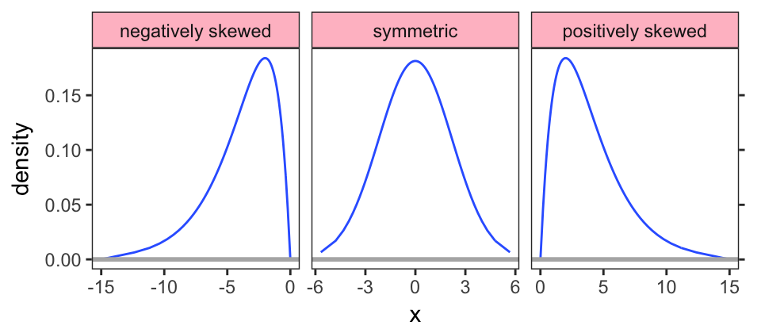

```r
pp <- ppoints(101)
zz.norm <- qnorm(pp, s=2.2)
dd.norm <- dnorm(zz.norm, s=2.2)
xx.chisq4 <- c(0,qchisq(pp, 4))
xx.chisq4 <- xx.chisq4[-102]
dd.chisq4 <- dchisq(xx.chisq4, 4)
df3.3 <- data.frame(x1 = zz.norm, x2 = xx.chisq4, x3 = -rev(xx.chisq4),
                    y1 = dd.norm, y2= dd.chisq4, y3 = rev(dd.chisq4),
                    z1 = rep("symmetric",101),
                    z2 = rep("positively skewed",101),
                    z3 = rep("negatively skewed",101))
df3.3 <- data.frame(x = c(df3.3$x1,df3.3$x2,df3.3$x3),
                    y = c(df3.3$y1,df3.3$y2,df3.3$y3),
                    z = c(as.character(df3.3$z1),
                          as.character(df3.3$z2),
                          as.character(df3.3$z3)))
df3.3$z <- factor(df3.3$z, levels = c("negatively skewed",
                                      "symmetric",
                                      "positively skewed"))
df.temp <- data.frame(x = c(-15,15),
                      y = c(0,0),
                      z = factor(c("negatively skewed","positively skewed"),
                                 levels = c("negatively skewed",
                                            "symmetric",
                                            "positively skewed")))
df3.3 <- rbind(df3.3,df.temp)

fig3.3 <- ggplot(df3.3,aes(x = x, y = y)) +
            geom_line(colour = "#3366FF") +
            geom_hline(yintercept = 0, colour = "grey70", size = 1) +
            facet_grid(.~z,scales = "free_x") +
            theme_bw() +
            scale_y_continuous( name = "density",
                                sec.axis = sec_axis(~.,
                                                    breaks = c(0,0.05,0.1,0.15),
                                                    labels = (rep("",4)))) +
            theme(strip.background = element_rect(fill = "pink"),
                  panel.grid.major = element_blank(),
                  panel.grid.minor = element_blank())

fig3.3
```

#### Fig 3.4

The second axis title on right of original figure is vertical aligened and should be readed from bottom to up. I decide to change that. Second axis title on right of current figure is also vertical aligened, however, should be readed from top to bottom.

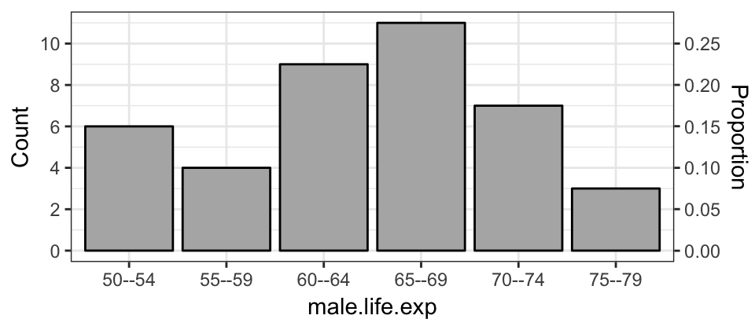

```r
library(HH)
data(tv)
tmp <- as.matrix(table(cut(tv$male.life.exp, breaks=seq(49.5,79.5,5))))
dimnames(tmp) <-
  list("Male Life Expectancy"=
         c("50--54","55--59","60--64","65--69","70--74","75--79"),
       " "="Frequency")
tmp <- data.frame(tmp)
tmp$Proportion <- tmp$Frequency/sum(tmp$Frequency)
tmp$x <- rownames(tmp)
Proportion <- as.character(tmp$Proportion)
fig3.4 <- ggplot(tmp, aes(x = x)) +
          geom_col(aes(y = Frequency), fill = "grey70", colour = "black") +
          theme_bw() +
          xlab("male.life.exp") +
          scale_y_continuous(breaks = seq(0,10,2),
                             name = "Count",
                             sec.axis = sec_axis(trans = ~./40,
                                                 breaks = seq(0,10,2)/40,
                                                 name = "Proportion"))
          ## theme(axis.title.y.right = element_text(angle = 90))
          ## change angle of title on second y axis. not necesscary

fig3.4
```

#### Fig3.5

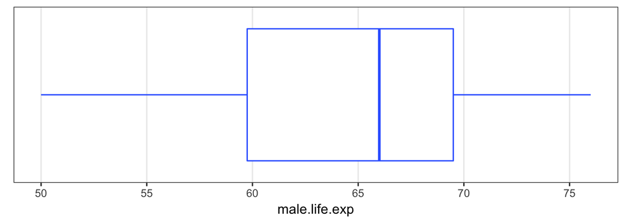

```r
df3.5 <- data.frame()
df3.5[1:40,"y"] <- as.numeric(tv$male.life.exp)
df3.5$x <- "male.life.exp"
fig3.5 <- ggplot(df3.5,aes(x = x, y = y)) +
          geom_boxplot(fill = "white", colour = "#3366FF") +
          scale_x_discrete(name = element_blank(),
                           label = element_blank(),
                           breaks = element_blank()) +
          scale_y_continuous(name = "male.life.exp",
                             breaks = seq(50,75,5)) +
          theme_bw() +
          theme(panel.grid.minor = element_blank()) +
          coord_flip()

fig3.5
```

#### Fig3.6

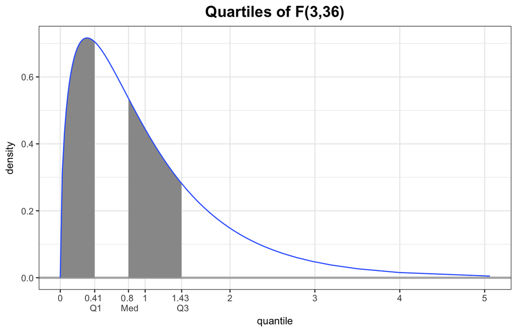

```r
pp <- ppoints(100)
pp <- c(0, pp[1:25], .25, pp[26:50], .50, pp[51:75], .75, pp[76:100])
q.pp <- qf(pp, df1=3, df2=36)
dd <- df(q.pp, df1=3, df2=36)
df3.6 <- data.frame( x = q.pp, y = dd)

x2 <- qf(0.25, df1=3, df2=36)
x2 <- seq(0,x2,0.005)
y2 <- df(x2, df1=3, df2=36)
df.temp1 <- data.frame(x = x2, y = y2)

x3.min <- qf(0.5, df1=3, df2=36)
x3.max <- qf(0.75, df1=3, df2=36)
x3 <- seq(x3.min,x3.max,0.005)
y3 <- df(x3, df1=3, df2=36)
df.temp2 <- data.frame(x = x3, y = y3)

fig3.6 <- ggplot(df3.6, aes(x = x, y = y)) +
          geom_hline(yintercept = 0, colour = "grey70", size = 1) +
          geom_area(data = df.temp1, fill = "grey60") +
          geom_area(data = df.temp2, fill = "grey60") +
          geom_line(data = df3.6,colour = "#3366FF") +
          scale_x_continuous(breaks = c(0,
                                        qf(0.25, df1=3, df2=36),
                                        qf(0.5, df1=3, df2=36),
                                        1,
                                        qf(0.75, df1=3, df2=36),
                                        2:5),
                             labels = c("0", "0.41 \n Q1","0.8 \n Med","1","1.43 \n Q3",paste0(2:5)),
                             minor_breaks = NULL) +
          theme_bw() +
          ggtitle("Quartiles of F(3,36)") +
          xlab("quantile") +
          ylab("density") +
          theme(plot.title = element_text(face = "bold", hjust = 0.5, size = 15),
                axis.title = element_text(size = 10))

fig3.6
```

#### Fig 3.7

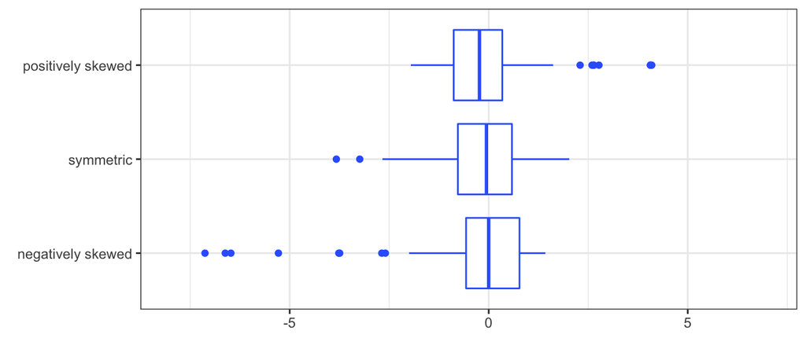

```r
sym <- rnorm(100)
neg <- sym[sym<0]
pos <- sym[sym>0]
neg.skew <- c(-neg^2, pos^.5)
pos.skew <- c(-(-neg)^.5, pos^2)
skew.levels <- c("negatively skewed", "symmetric", "positively skewed")
skew.df <- data.frame(y=c(neg.skew, sym, pos.skew),
                      dist=ordered(rep(skew.levels, c(100,100,100)),
                                   levels=skew.levels))

df3.7 <- skew.df
colnames(df3.7) <- c("y","x")

fig3.7 <- ggplot(df3.7, aes(x = x, y = y)) +
          geom_boxplot(colour = "#3366FF") +
          coord_flip() +
          scale_x_discrete(name = element_blank()) +
          scale_y_continuous(name = element_blank(),
                             limits = c(-8,7),
                             breaks = seq(-5,5,5),
                             labels = paste0(seq(-5,5,5))) +
          theme_bw()

fig3.7
```

#### Fig3.11

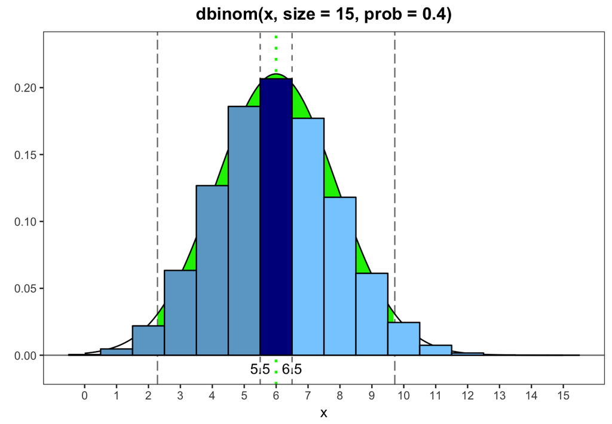

```r
qq <- 0:15
yy <- dbinom(qq,size=15, prob=.4)
df3.11 <- data.frame(x = qq, y = yy)
df3.11[8:16,"colour"] <- "light"
df3.11[1:6,"colour"] <- "darker"
df3.11[7,"colour"] <- "darkest"

x <- seq(0,15,0.005)
y <- dnorm(x,mean = 6,sd=sqrt(15*.4*(1-.4)))

df.temp <- data.frame(x = x, y = y)

x1 <- qnorm(0.025, mean = 6,sd=sqrt(15*.4*(1-.4)))
x2 <- qnorm(1-0.025, mean = 6,sd=sqrt(15*.4*(1-.4)))

df.temp1 <- data.frame(x = seq(x1,x2,0.05))
df.temp1$y <- dnorm(df.temp1$x, mean = 6,sd=sqrt(15*.4*(1-.4)))

df.text <- data.frame( x = c(5.5,6.5),
                       y = c(-0.01,-0.01),
                       z = c("5.5","6.5"))

fig3.11 <- ggplot(df3.11, aes(x = x, y = y)) +
           geom_hline(yintercept = 0, colour = "grey50") +
           geom_area(data = df.temp1 , aes(x = x, y = y), fill = "green2") +
           geom_vline(xintercept = c(x1,x2), linetype = "longdash",colour = "grey50") +
           geom_vline(xintercept = 6, colour = "green2", size = 1, linetype = "dotted") +
           geom_vline(xintercept = c(5.5,6.5), linetype = "dashed", colour = "grey50") +
           geom_line(data = df.temp , aes(x = x, y = y), colour = "black") +
           geom_col(colour = "black", aes(fill = colour), width = 1) +
           scale_fill_manual(values = c("skyblue3","darkblue","skyblue1")) +
           geom_text(data = df.text, aes(x = x, y = y, label = factor(z))) +
           ggtitle("dbinom(x, size = 15, prob = 0.4)") +
           theme_bw() +
           scale_x_continuous(breaks = 0:15, labels = paste0(0:15)) +
           scale_y_continuous(limits = c(-0.01,0.23), name = element_blank()) +
           theme(legend.position = "none",
                 panel.grid = element_blank(),
                 plot.title = element_text(hjust = 0.5, face = "bold"))

fig3.11
```

#### Fig3.12

```r
pp <- ppoints(100)
xx <- qnorm(pp)
yy <- dnorm(xx)
cc <- pnorm(xx)

df3.12.1 <- data.frame(x = xx, y = yy, class = as.character(expression("Density"~phi(z))))
df3.12.2 <- data.frame(x = xx, y = cc, class = as.character(expression("probability CDF"~phi(z))))

qnorm(0.95)
```

```
## [1] 1.644854
```

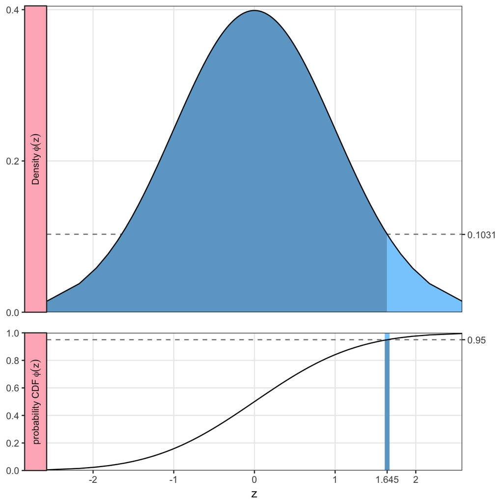

```r
df3.12.1.area1 <- df3.12.1[df3.12.1$x <= 1.645,c("x","y")]
df.comb <- data.frame(x = seq(1.600,1.645, 0.005))
df.comb$y <- dnorm(df.comb$x)
df3.12.1.area1 <- rbind(df3.12.1.area1,df.comb)

df3.12.1.area2 <- df3.12.1[! df3.12.1$x < 1.645,c("x","y")]
df.comb <- data.frame(x = seq(1.645,1.695, 0.005))
df.comb$y <- dnorm(df.comb$x)
df3.12.1.area2 <- rbind(df.comb, df3.12.1.area2)

fig3.12.1 <- ggplot(df3.12.1, aes(x = x, y = y)) +
             geom_hline(yintercept = 0.1031, linetype = "dashed", colour = "grey50") +
             geom_area(data = df3.12.1.area1, aes(x =x, y = y), fill = "skyblue3") +
             geom_area(data = df3.12.1.area2, aes(x =x, y = y), fill = "skyblue1") +
             geom_line() +
             facet_grid(class~., switch = "y", labeller = label_parsed) +
             scale_x_continuous( expand = c(0,0),
                                 name = element_blank()) +
             scale_y_continuous( expand = c(0,0),
                                 limits = c(0,0.405),
                                 breaks = c(0,0.2,0.4),
                                 labels = paste0(c("0.0",0.2,0.4)),
                                 sec.axis = sec_axis(~., breaks = 0.1031)) +
             theme_bw() +
             theme(strip.background = element_rect(fill = "lightpink"),
                   axis.title.y = element_blank(),
                   panel.grid.minor = element_blank(),
                   axis.text.x = element_blank(),
                   axis.ticks.x = element_blank())

df3.12.2.area <- data.frame(x = c(rep(1.645-.03,2),rep(1.645+.03,2)),
                            y = rep(c(1,0.95),2))


fig3.12.2 <- ggplot(df3.12.2, aes(x = x, y = y)) +
             geom_hline(yintercept = 0.95, linetype = "dashed", colour = "grey50") +
             geom_ribbon(data = df3.12.2.area, aes(x = x,ymin = 0.95, ymax = 1), fill = "skyblue1") +
             geom_ribbon(data = df3.12.2.area, aes(x = x,ymin = 0, ymax = 0.95), fill = "skyblue3") +
             geom_line() +
             facet_grid(class~., switch = "y", labeller = label_parsed) +
             scale_x_continuous(expand = c(0,0),
                                breaks = sort(c(seq(-2,2,1),1.645)),
                                labels = paste0(sort(c(seq(-2,2,1),1.645))),
                                name = "z") +
             scale_y_continuous(breaks = seq(0,1,0.2),
                                labels = c("0.0","0.2","0.4","0.6","0.8","1.0"),
                                expand = c(0,0),
                                sec.axis = sec_axis(~., breaks = 0.95)) +
             theme_bw() +
             theme(strip.background = element_rect(fill = "lightpink"),
                   axis.title.y = element_blank(),
                   panel.grid.minor = element_blank())


plot_grid(fig3.12.1, fig3.12.2, align = "v", nrow = 2, rel_heights = c(0.65,0.35))
```